# Assignment7

```r
library(tidyverse)
library(broom)
```

## a) Read in and display (some of) the data.

```r
url <- "http://ritsokiguess.site/datafiles/open-space.csv"
data <- read_csv(url)
head(data)
```

| city | population | open_space |
| --- | --- | --- |
| Baltimore | 651 | 5091 |
| Boston | 589 | 4865 |
| Chicago | 2896 | 11645 |
| Long Beach | 462 | 2887 |
| Los Angeles | 3695 | 29801 |
| Miami | 362 | 1329 |

## b) Make a suitable plot of these data, bearing in mind the aims of the analysis. Add a regression line to your plot.

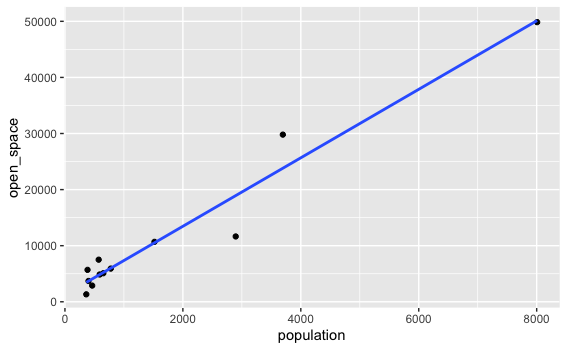

```r
data %>%
  ggplot(aes(x = population, y = open_space)) + geom_point()+ geom_smooth(method = "lm", se = FALSE, formula=y~x)
```

## c) Fit a regression predicting open space from population, and display the results.

```r
pred <- lm(data = data, open_space~population)
tidy(pred)
```

| term | estimate | std.error | statistic | p.value |
| --- | --- | --- | --- | --- |
| (Intercept) | 1248.197462 | 1198.5499203 | 1.041423 | 3.222027e-01 |
| population | 6.104994 | 0.4356582 | 14.013266 | 6.711342e-08 |

## d)Is there a significant effect of population on the amount of open space? Explain briefly. What does this mean, in the context of the data?

p-value = 6.711342e-08. let H0: the slope = 0, H1: the slope $\neq$ 0. Because p-value is less than 0.05. we reject H0 and the slope of the population is not 0. Therefore, there is a significant effect of population on the amount of open space.

In the context of the data, this means: if a city’s population increases a thousand, the area of the open space will also increase 6.104994.

## e) When some of the values of a variable are much larger than others, a common strategy is to take logs of all such variables (both the quantitative variables, here). Find a way to re-draw your scatterplot on log-scales for both variables. Cite your source, or describe your thought process, as appropriate. (In R, log means natural (base e) log, which is fine here.)

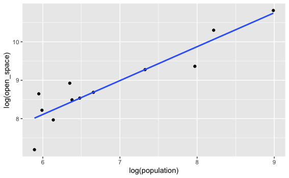

```r
data %>% ggplot(aes(x = log(population), y = log(open_space))) + geom_point() + geom_smooth(method = "lm", se = FALSE, formula=y~x)
```

If two numbers are very different, then when I take the logs of each of them, they’re going to be very close. So we can narrow the difference by taking the log. This is also learned from box-cox transformation from lecture 9(c).

## f)Run a regression predicting log-open space from log-population. Display the results.

```r
data %>%
mutate(log_population = log(population), log_OS = log(open_space)) -> log
log
```

| city | population | open_space | log_population | log_OS |
| --- | --- | --- | --- | --- |
| Baltimore | 651 | 5091 | 6.478510 | 8.535230 |
| Boston | 589 | 4865 | 6.378426 | 8.489822 |
| Chicago | 2896 | 11645 | 7.971086 | 9.362632 |
| Long Beach | 462 | 2887 | 6.135565 | 7.967973 |
| Los Angeles | 3695 | 29801 | 8.214736 | 10.302297 |
| Miami | 362 | 1329 | 5.891644 | 7.192182 |
| Minneapolis | 383 | 5694 | 5.948035 | 8.647168 |
| New York | 8008 | 49854 | 8.988196 | 10.816854 |
| Oakland | 399 | 3712 | 5.988961 | 8.219326 |
| Philadelphia | 1518 | 10685 | 7.325149 | 9.276596 |

[output cut: 2 more lines]

```r
pred2 <- lm(data = log, log_OS~log_population)
tidy(pred2)
```

| term | estimate | std.error | statistic | p.value |
| --- | --- | --- | --- | --- |
| (Intercept) | 2.8150528 | 0.8294266 | 3.393975 | 6.839982e-03 |
| log_population | 0.8823341 | 0.1196830 | 7.372256 | 2.390939e-05 |

## g) Using your regression of the previous part, predict the amount of open space in a city that has a population of 500 (thousand). Show your process.

```r
new_population <- tibble(log_population = log(500))
pred3 <- predict(pred2, new_population)
exp(pred3)
```

```
       1
4017.493
```